# The Moral Dilution Effect

26 July 2022

## Overview

> Cillian McHugh - 26/7/22
- Background
- Study 1: bad characters ([results](https://cillianmiltown.github.io/moral_dilution_online/study1_sample_analysis.html))
- Study 2: good characters ([results](https://cillianmiltown.github.io/moral_dilution_online/study4_sample_analysis.html))
- Study 3: both good and bad ([results](https://cillianmiltown.github.io/moral_dilution_online/study5_sample_analysis.html))
- Study 4: good characters ([results](https://cillianmiltown.github.io/moral_dilution_online/study4_rep_sample_analysis.html))
- Study 5: both good and bad (between subjects) ([results](https://cillianmiltown.github.io/moral_dilution_online/study5_sample_analysis.html))
- Overview of results [here](https://cillianmiltown.github.io/moral_dilution_online/update_presentation_scroll.html)

## Background

## The Dilution Effect

> Cillian McHugh - 26/7/22
- Diagnostic information about a target is ‘diluted’ by non-diagnostic information about a target (Nisbett, Zukier, & Lemley, 1981; Zukier, 1982; Igou & Bless, 2007; Kemmelmeier, 2007; Tetlock & Boettger, 1989)
- Shown for
  - judging products (Igou & Bless, 2005; Meyvis & Janiszewski, 2002)
  - probability judgments (LaBella & Koehler, 2004)
  - and predictions relating to people’s behavior (Nisbett et al., 1981; Zukier, 1982),

## Examples:

> Cillian McHugh - 26/7/22

**Example 1:**

- Task: Predict the GPA of a student (from Zukier, 1982)
  - Diagnostic information: “He quite often starts things he doesn’t finish”
  - Non-diagnostic information: “A few times a year he is bothered by bad dreams”

**Example 2:**

- Task: Predict if a coffee machine would be sold (from Igou & Bless, 2007)
  - Diagnostic information: “It has an automatic off switch”
  - Non-diagnostic information: “It has three buttons”

## Explaining the Dilution Effect

> Cillian McHugh - 26/7/22
- Representativeness heuristic and Category Typicality
- In categorization:
  - *furniture*: *chair* vs *bookend*
- Dilution and typicality
  - **Diagnostic information only**: Very representative (or typical)
  - **Non-Diagnostic information included**: Very less representative (or less typical)
- One prediction of MJAC is that moral categorizations should vary in typicality
  - Specifically, MJAC “predicts differences in typicality ratings when controlling for severity” (McHugh et al., 2022, p. 143)

## Moral Dilution

> Cillian McHugh - 26/7/22
- 5 studies
- Pre-registered
- Dilution effect should be observed for judgments of Moral Character

## Studies

## Study 1: Bad Characters

> Cillian McHugh - 26/7/22

## Study 1: Design

> Cillian McHugh - 26/7/22
- Within subjects design
  - IV: Diagnostic information (present/absent)
  - 4 descriptions
  - Randomly assigned to contain diagnostic information vs not
- Imagine a person named Sam. Throughout their life they have been known to be cruel, act unfairly, and to betray their own group.
- Imagine a person named Sam. Throughout their life they have been known to be cruel, act unfairly, and to betray their own group. *They are left-handed, drink tea in the morning, and have two older siblings and one younger sibling.*

## Materials: Moral Descriptions

> Cillian McHugh - 26/7/22
- Imagine a person named Sam. Throughout their life they have been known to be cruel, act unfairly, and to betray their own group.
- Imagine a person named Robin. Throughout their life they have been known to physically hurt others, treat some people differently to others, and show lack of loyalty.
- Imagine a person named Francis. Throughout their life they have been known to violate the standards of purity and decency, show lack of respect for authority, and treat people unequally.
- Imagine a person named Alex. Throughout their life they have been known to cause others to suffer emotionally, to deny others their rights, and to cause chaos or disorder.

## Materials: Non-Diagnostic

> Cillian McHugh - 26/7/22
- They have red hair, play tennis four times a month, and have one older sibling and one younger sibling.
- They are left-handed, drink tea in the morning, and have two older siblings and one younger sibling.

## Study 1: Measures & Participants

> Cillian McHugh - 26/7/22
- DV1: MPS-4: Moral perceptions scale (Walker et al., 2021):
  - 7-point Likert
  - 4 items: Bad-Good, Moral-Immoral, Violent-Peaceful, Merciless-Empathetic
  - Cronbach’s alpha = 0.83
- DV2: MM-1: Single item of moral perception (Walker et al., 2021).
  - 0-100 slider scale
  - Very Immoral-Very Moral

UL Students with a total sample of *N* = 801, (female = 496, male = 283, non-binary/other = 17, prefer not to say 3, *M<sub>age</sub>* = 26.2, *SD* = 10.2).

## Study 1: Results

> Cillian McHugh - 26/7/22

✅ Diagnostic descriptions rated as more immoral than the non-diagnostic

**MPS-4**

- The model significantly predicted responses, \(\chi\)<sup>2</sup>(8) = 816.91, *p* < .001.
- Condition significantly influenced responses *F*(1, 799.42) = 51.47, *p* < .001
- and was a significant predictor, \(b\) = -0.08, *t*(799.42) = -7.17, *p* < .001

**MM-1**

- The model significantly predicted responses, \(\chi\)<sup>2</sup>(8) = 475.52, *p* < .001.
- Condition significantly influenced responses *F*(1, 799.71) = 44.39, *p* < .001
- and was a significant predictor, \(b\) = -1.22, *t*(799.71) = -6.66, *p* < .001

## Study 1: Results

> Cillian McHugh - 26/7/22

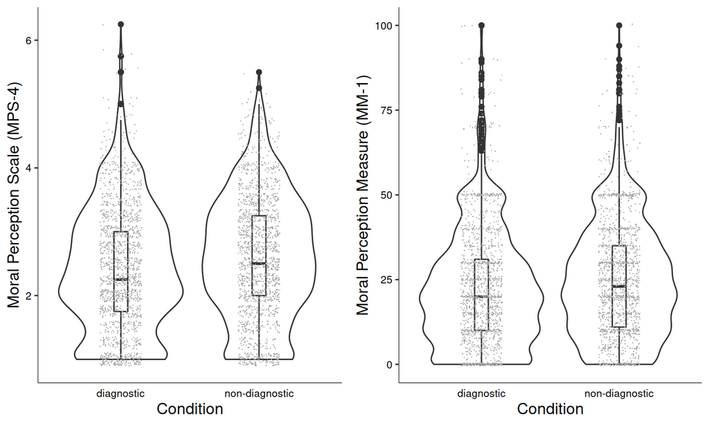

## Study 2: Good Characters

> Cillian McHugh - 26/7/22
- Study 1 showed Dilution effect for Morally *Bad* Characters
- Study 2 tests Dilution effect for Morally *Good* characters

## Study 2: Design

> Cillian McHugh - 26/7/22
- Within subjects design
  - IV: Diagnostic information (present/absent)
  - 4 descriptions
  - Randomly assigned to contain diagnostic information vs not
- Imagine a person named Sam. Throughout their life they have been known to always help and care for others, treat everyone fairly and equally, and show a strong sense of loyalty to others.
- Imagine a person named Sam. Throughout their life they have been known to always help and care for others, treat everyone fairly and equally, and show a strong sense of loyalty to others. *They have dark hair, go for a jog twice a week, and their favourite colour is blue*

## Materials: Moral Descriptions

> Cillian McHugh - 26/7/22
- Imagine a person named Sam. Throughout their life they have been known to always help and care for others, treat everyone fairly and equally, and show a strong sense of loyalty to others.
- Imagine a person named Robin. Throughout their life they have been known to show compassion and empathy for others, act with a sense of fairness and justice, and, never to break their word.
- Imagine a person named Francis. Throughout their life they have been known to uphold the standards of purity and decency, show respect for authority, and to always act honestly and fairly.
- Imagine a person named Alex. Throughout their life they have been known to protect and provide shelter to the weak and vulnerable, uphold the rights of others, and show respect for authority.

## Materials: Non-Diagnostic

> Cillian McHugh - 26/7/22
- They have dark hair, go for a jog twice a week, and their favourite colour is blue.
- They have blue eyes, drink coffee in the morning, and their favourite colour is green.

## Study 2: Measures (same as Study 1)

> Cillian McHugh - 26/7/22
- DV1: MPS-4: Moral perceptions scale (Walker et al., 2021):
  - 7-point Likert
  - 4 items: Bad-Good, Moral-Immoral, Violent-Peaceful, Merciless-Empathetic
  - Cronbach’s alpha = 0.85
- DV2: MM-1: Single item of moral perception (Walker et al., 2021).
  - 0-100 slider scale
  - Very Immoral-Very Moral

## Study 2: Participants

> Cillian McHugh - 26/7/22

Total sample of *N* = 820, (female = 466, male = 337, non-binary/other = 15, prefer not to say 4, *M<sub>age</sub>* = 29, *SD* = 10.9).

The majority of participants were from the student body: *n* = 533, (female = 370, male = 147, non-binary/other = 14, prefer not to say 3, *M<sub>age</sub>* = 25.5, *SD* = 9.6).

In order to reach our pre-registered target sample size we recruited additional participants from MTurk: *n* = 287, (female = 96, male = 190, non-binary/other = 1, prefer not to say 1, *M<sub>age</sub>* = 35.7, *SD* = 10.1).

## Study 2: Results

> Cillian McHugh - 26/7/22

❌ No effect for condition!

**MPS-4**

- The model significantly predicted responses, \(\chi\)<sup>2</sup>(8) = 160, *p* < .001.
- No effect for condition *F*(1, 838.12) = 0.24, *p* = .624
- not a significant predictor, \(b\) = 0, *t*(838.12) = 0.49, *p* = .624

**MM-1**

- The model significantly predicted responses, \(\chi\)<sup>2</sup>(8) = 75.69, *p* < .001.
- No effect for condition *F*(1, 2453.06) = 1.23, *p* = .267
- not a significant predictor, \(b\) = 0.16, *t*(2453.06) = 1.11, *p* = .267

## Study 2: Results

> Cillian McHugh - 26/7/22

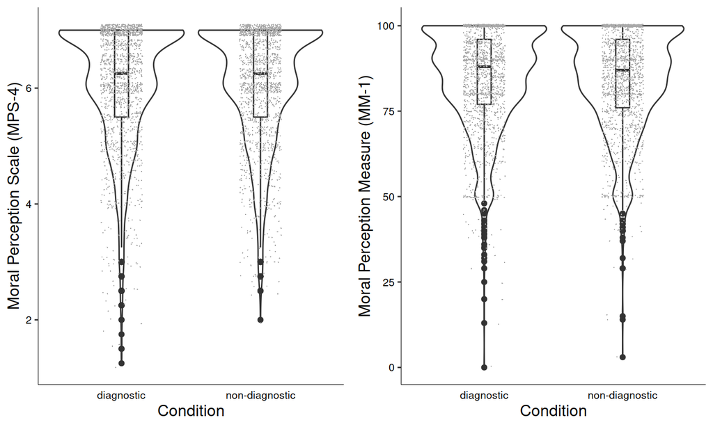

## Study 3: Both Good and Bad Characters

> Cillian McHugh - 26/7/22

✅ Study 1: Bad Characters

❌ Study 2: Good Characters

- Does diltion effect depend on valence?

## Study 3: Design

> Cillian McHugh - 26/7/22
- Both *good* and *bad* characters
- Within subjects factorial design
  - IV1: Diagnostic information (present/absent)
  - IV2: Valence of description (good/bad)
- 4 descriptions (2 good, 2 bad)
  - **Good**: Sam & Robin
  - **Bad**: Alex & Francis
- Randomly assigned to contain diagnostic information vs not

## Study 3 (descriptions)

> Cillian McHugh - 26/7/22
- Imagine a person named Sam. Throughout their life they have been known to always help and care for others, treat everyone fairly and equally, and show a strong sense of loyalty to others.
- Imagine a person named Robin. Throughout their life they have been known to show compassion and empathy for others, act with a sense of fairness and justice, and, never to break their word.
- Imagine a person named Alex. Throughout their life they have been known to be cruel, act unfairly, and to betray their own group.
- Imagine a person named Francis. Throughout their life they have been known to physically hurt others, treat some people differently to others, and show lack of loyalty.

## Study 3 (non-diagnostic)

> Cillian McHugh - 26/7/22
- They have red hair, play tennis four times a month, and have one older sibling and one younger sibling.
- They are left-handed, drink tea in the morning, and have two older siblings and one younger sibling.

## Study 3: Measures and Partcipants

> Cillian McHugh - 26/7/22
- DV1: Moral perceptions scale, 7-point Likert; 4 items: Bad-Good, Moral-Immoral, Violent-Peaceful, Merciless-Empathetic; Cronbach’s alpha = 0.94
- DV2: Single item of moral perception; 0-100 slider scale; Very Immoral-Very Moral

MTurk sample of *N* = 874, (female = 320, male = 550, non-binary/other = 4, prefer not to say 2, *M<sub>age</sub>* = 36.4, *SD* = 10.7).

## Study 3: Results: Interaction

> Cillian McHugh - 26/7/22

**MPS-4**: model was significant \(\chi\)<sup>2</sup>(5) = 4554.31, *p* < .001.

- ✅ Main effect for Condition, *F*(1, 873) = 8.61, *p* = .003;
- ✅ Main effect for valence, *F*(1, 873) = 1859.34, *p* < .001;
- ❌ No condition \(\times\) valence interaction, *F*(1, 873) = 0.01, *p* = .935.

**MM-1**: model was significant \(\chi\)<sup>2</sup>(5) = 3433.96, *p* < .001.

- ✅ Main effect for Condition, *F*(1, 873) = 16.61, *p* < .001;
- ✅ Main effect for valence, *F*(1, 873) = 986.37, *p* < .001;
- ❌ No condition \(\times\) valence interaction, *F*(1, 873) = 0.04, *p* = .849.

## Study 3: Results: Bad Characters

> Cillian McHugh - 26/7/22

**MPS-4**

- ❌ The model was not significant, \(\chi\)<sup>2</sup>(3) = 5.4, *p* = .145.
- ❌ No effect for condition *F*(1, 872) = 3.54, *p* = .060
- ❌ not a significant predictor, \(b\) = -0.03, *t*(872) = -1.88, *p* = .060

**MM-1**

- ✅ model was significant, \(\chi\)<sup>2</sup>(3) = 8.67, *p* = .034.
- ✅ main effect for condition *F*(1, 872) = 7.01, *p* = .008
- ✅ significant predictor, \(b\) = -0.69, *t*(872) = -2.65, *p* = .008

## Study 3: Results Bad Characters

> Cillian McHugh - 26/7/22

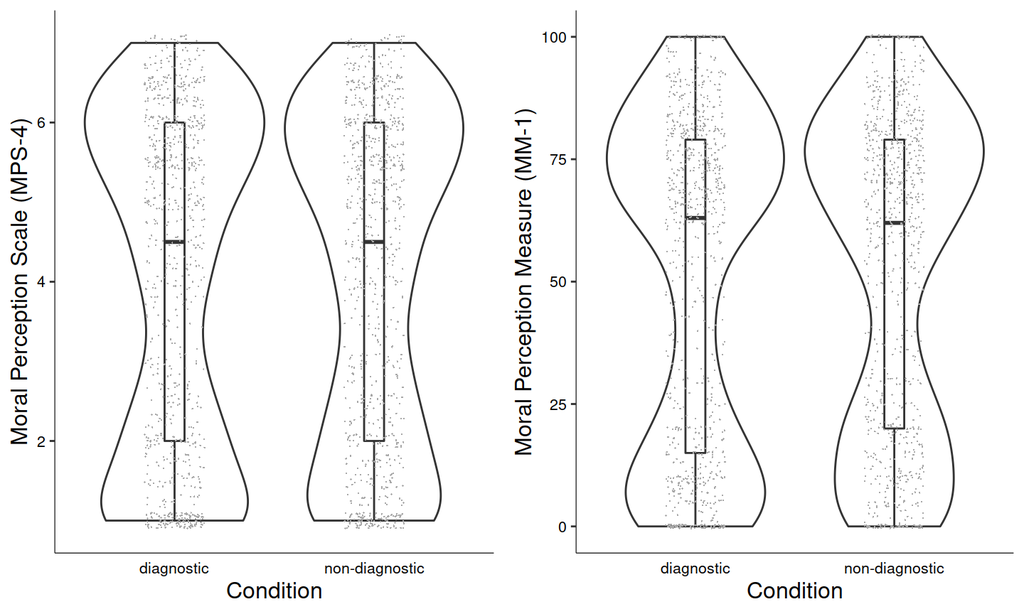

## Study 3: Results: Good Characters

> Cillian McHugh - 26/7/22

**MPS-4**

- ✅ The model was significant, \(\chi\)<sup>2</sup>(3) = 13.66, *p* = .003.
- ✅ Significant effect for condition *F*(1, 872) = 6.82, *p* = .009
- ✅ significant predictor, \(b\) = 0.03, *t*(872) = 2.61, *p* = .009

**MM-1**

- ✅ model was significant, \(\chi\)<sup>2</sup>(3) = 14.62, *p* = .002.
- ✅ main effect for condition *F*(1, 872) = 12.01, *p* < .001
- ✅ significant predictor, \(b\) = 0.63, *t*(872) = 3.47, *p* < .001

## Study 3: Results Good Characters

> Cillian McHugh - 26/7/22

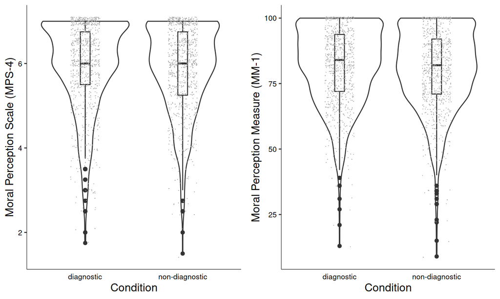

## Study 4 Good Characters

- Inconsistent results for Good characters between Study 2 and Study 3
- Replication of Study 2

## Study 4: Design

> Cillian McHugh - 26/7/22
- Within subjects design
  - IV: Diagnostic information (present/absent)
  - 4 descriptions
  - Randomly assigned to contain diagnostic information vs not
- Imagine a person named Sam. Throughout their life they have been known to always help and care for others, treat everyone fairly and equally, and show a strong sense of loyalty to others.
- Imagine a person named Sam. Throughout their life they have been known to always help and care for others, treat everyone fairly and equally, and show a strong sense of loyalty to others. *They have dark hair, go for a jog twice a week, and their favourite colour is blue*

## Materials: Moral Descriptions

> Cillian McHugh - 26/7/22
- Imagine a person named Sam. Throughout their life they have been known to always help and care for others, treat everyone fairly and equally, and show a strong sense of loyalty to others.
- Imagine a person named Robin. Throughout their life they have been known to show compassion and empathy for others, act with a sense of fairness and justice, and, never to break their word.
- Imagine a person named Francis. Throughout their life they have been known to uphold the standards of purity and decency, show respect for authority, and to always act honestly and fairly.
- Imagine a person named Alex. Throughout their life they have been known to protect and provide shelter to the weak and vulnerable, uphold the rights of others, and show respect for authority.

## Materials: Non-Diagnostic

> Cillian McHugh - 26/7/22
- They have dark hair, go for a jog twice a week, and their favourite colour is blue.
- They have blue eyes, drink coffee in the morning, and their favourite colour is green.

## Study 4: Measures and Participants

> Cillian McHugh - 26/7/22
- DV1: MPS-4: Moral perceptions scale (Walker et al., 2021):
  - 7-point Likert
  - 4 items: Bad-Good, Moral-Immoral, Violent-Peaceful, Merciless-Empathetic
  - Cronbach’s alpha = 0.81
- DV2: MM-1: Single item of moral perception (Walker et al., 2021).
  - 0-100 slider scale
  - Very Immoral-Very Moral

Total sample of *N* = 856, (female = 347, male = 507, non-binary/other = 2, prefer not to say 1, *M<sub>age</sub>* = 37.1, *SD* = 11).

## Study 4: Results

> Cillian McHugh - 26/7/22

**MPS-4**

- ✅ was model significant, \(\chi\)<sup>2</sup>(8) = 17.86, *p* = .022.
- ❌ No effect for condition *F*(1, 866.6) = 2.8, *p* = .095
- ❌ not a significant predictor, \(b\) = 0.01, *t*(866.6) = 1.67, *p* = .095

**MM-1**

- ✅ The model was significant, \(\chi\)<sup>2</sup>(8) = 40.1, *p* < .001.
- ✅ main effect for condition *F*(1, 864.45) = 4.79, *p* = .029
- ✅ significant predictor, \(b\) = 0.29, *t*(864.45) = 2.19, *p* = .029

## Study 4: Results

> Cillian McHugh - 26/7/22

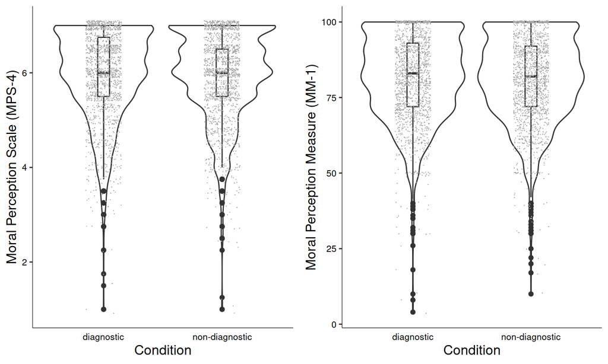

## Study 5: Both: Between-Subjects Design

> Cillian McHugh - 26/7/22
- Mixed Results Studies 1-4
- Clear effect for *Bad* in Study 1, but less so in Study 3
- Effect for *Good* in Study 3 but less so in Studies 2 & 4
- Comparison/contrast effect as a confound?

## Study 5 Design

> Cillian McHugh - 26/7/22
- Same materials and measures as Study 3 but with a Between Subjects Design
- Participants read 1 scenario
- 2 IVs:
  - valence (good/bad)
  - condition (diagnostic/non-diagnostic)

## Study 5 Measures and Participants

> Cillian McHugh - 26/7/22
- DV1: Moral perceptions scale, 7-point Likert; 4 items: Bad-Good, Moral-Immoral, Violent-Peaceful, Merciless-Empathetic; Cronbach’s alpha = 0.97
- DV2: Single item of moral perception; 0-100 slider scale; Very Immoral-Very Moral

MTurk sample of *N* = 1750, (female = 858, male = 879, non-binary/other = 12, prefer not to say 8, *M<sub>age</sub>* = 37.8, *SD* = 15.8)..

## Study 5 Results: Interaction

> Cillian McHugh - 26/7/22

**MPS-4**

- ✅ Main effect for condition: *F*(1, 1746) = 5.78, *p* = .016;
- ✅ Main effect for valence *F*(1, 1746) = 1408.65, *p* < .001;
- ❌ No condition \(\times\) valence interaction, *F*(1, 1746) = 0, *p* = .985.

**MM-1**

- ✅ Main effect for condition: *F*(1, 1746) = 9.94, *p* = .002;
- ✅ Main effect for valence *F*(1, 1746) = 559.61, *p* < .001;
- ❌ No condition \(\times\) valence interaction, *F*(1, 1746) = 0.12, *p* = .732.

## Study 5 Results: Bad Characters

> Cillian McHugh - 26/7/22

**MPS-4**

- ❌ No significant difference in responses depending on condition, *t*(834.36) = -1.23, *p* = .221, *d* = 0.08.
  - diagnostic condition *M* = 3.63, *SD* = 2.21
  - non-diagnostic condition *M* = 3.81, *SD* = 2.03

**MM-1**

- ❌ No significant difference in responses depending on condition, *t*(843.09) = -1.48, *p* = .140, *d* = 0.1
  - diagnostic condition *M* = 43.35, *SD* = 35.56
  - non-diagnostic condition *M* = 46.86, *SD* = 33.85

## Study 5 Results: Bad Characters

> Cillian McHugh - 26/7/22

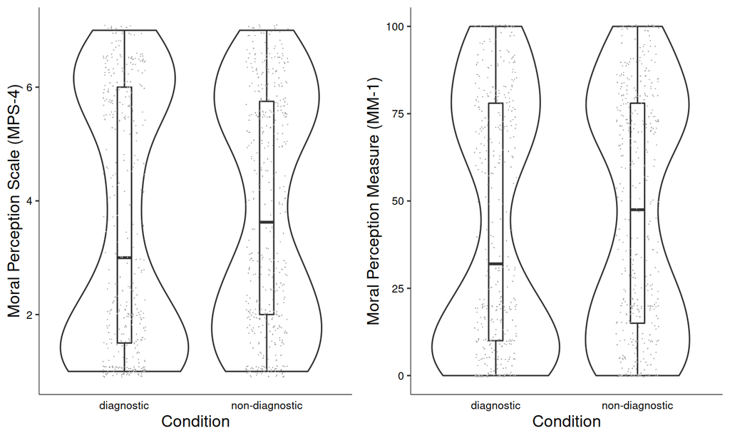

## Study 5 Results: Good Characters

> Cillian McHugh - 26/7/22

**MPS-4**

- ✅ Significant difference in responses depending on condition, *t*(886.55) = 3.16, *p* = .002, *d* = 0.21.
  - diagnostic condition *M* = 6.25, *SD* = 0.84
  - non-diagnostic condition *M* = 6.07, *SD* = 0.87

**MM-1**

- ✅ Significant difference in responses depending on condition, *t*(883.93) = 4.4, *p* < .001, *d* = 0.29
  - diagnostic condition *M* = 87.11, *SD* = 13.75
  - non-diagnostic condition *M* = 82.74, *SD* = 15.89

## Study 5 Results: Good Characters

> Cillian McHugh - 26/7/22

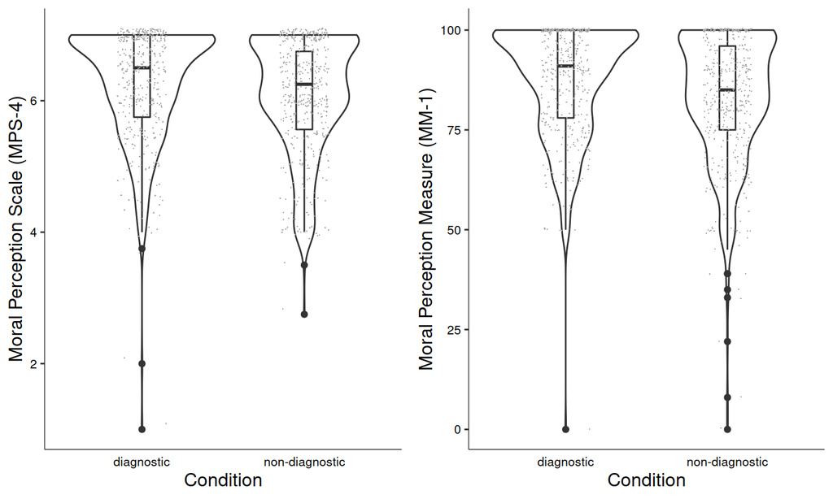

## Aggregate Results

> Cillian McHugh - 26/7/22

A mini meta-analysis and found a significant dilution effect across both good and bad character descriptions across all studies \(\chi\)<sup>2</sup>(28) = 133.141, *p* < .001 (Fisher’s method); or when weighting for sample size, *z* = 7.878, *p* < .001 (Stouffer’s Z-score method).

A mini meta-analysis and found a significant dilution effect for bad character descriptions across all studies \(\chi\)<sup>2</sup>(12) = 59.076, *p* < .001 (Fisher’s method); or when weighting for sample size, *z* = 5.364, *p* < .001 (Stouffer’s Z-score method).

A mini meta-analysis and found a significant dilution effect for good character descriptions across all studies \(\chi\)<sup>2</sup>(16) = 74.065, *p* < .001 (Fisher’s method); or when weighting for sample size, *z* = 5.778, *p* < .001 (Stouffer’s Z-score method).

## Summary

> Cillian McHugh - 26/7/22

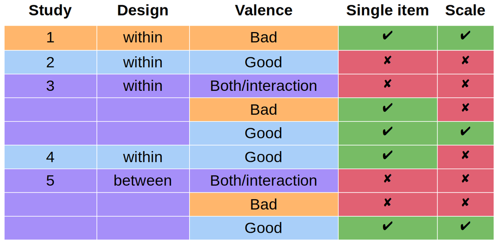

## Summary

> Cillian McHugh - 26/7/22

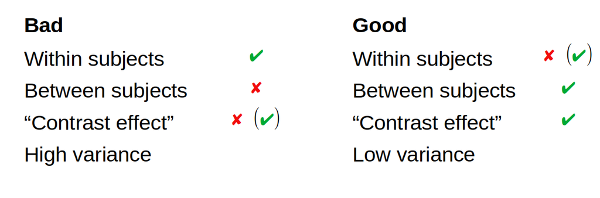

## Summary

> Cillian McHugh - 26/7/22
- There is a convincing effect for *bad* characters when they are contrasted against other *bad* characters. But this effect shrinks (or disappears) when they are contrasted against *good* characters.
- There is a convincing effect for *good* characters when there is no contrast, or when they can be contrasted against *bad* characters; but this disappears (or shrinks) when other *good* characters are the only contrast.